# Study 3: Results Overview

# 1 Methods

## 1.1 Design and procedure

A double blind, between-participants experimental design was employed in the study. The study was presented as a survey on attitudes toward meat consumption. All participants were directed from their recruitment platform to a Qualtrics survey. There were 3 conditions. In the experimental condition, participants read a normative statement depicting a trending minority norm. In the control conditions, participants either read a statement depicting a minority norm, or did not read any text and so proceeded to the dependent measures without an intervening task.

After participants read the statements, they completed dependent measures relating to meat consumption, followed by demographic questions and a measure of conformity.

## 1.3 Normative statements

**Trending norm.** In the trending norm condition, the text read: ‘Research from early 2020 has found that 48% of British people engage in one or more of the following behaviours:

• Eating small portions of meat • Opting out of eating meat several days of the week • Adopting a vegan/vegetarian diet

This has increased from 37% in 2018.’

**Minority norm.** In the minority norm condition, the text read: ‘Research from early 2020 has found that 48% of British people engage in one or more of the following behaviours:

• Eating small portions of meat • Opting out of eating meat several days of the week • Adopting a vegan/vegetarian diet’

**No norm control.** The no norm control condition did not have any text.

## 1.4 Measures

**Demographic questions.** Participants answered questions relating to their demographic characteristics (e.g., age, gender, political position; see Appendix A).

**Dependent measures.** We measured interest in eating less meat, attitudes towards eating meat, intentions and expectations to limit own meat consumption. Additionally, we measured expectations about future meat consumption. All primary outcomes were measured using single item measures.

*Interest.* To measure interest in limiting meat consumption, participants responded to the statement: “I am interested in eating less meat” on a 0-100 scale (0 = Not at all interested, 50 = Somewhat interested, 100 = Extremely interested).

*Attitudes.* To measure attitudes, participants responded to the statement: “My attitude towards eating less meat is…” on a 0-100 slider scale (0 = Extremely unfavourable, 50 = Neither unfavourable nor favourable, 100 = Extremely favourable).

*Intentions.* To measure intentions, participants responded to the statement: “I intend to eat less meat within the next year” on a 0-100 slider scale (0 = Very strongly disagree, 50 = Neither agree nor disagree, 100 = Very strongly agree).

*Expectations*. To measure expectations, participants responded to the statement: “I expect to eat less meat within the next year” on a 0-100 slider scale (0 = Very strongly disagree, 50 = Neither agree nor disagree, 100 = Very strongly agree).

*Estimates of future meat consumption.* Participants responded to 3 statements estimating the meat consumption of British people “THIS year,” “NEXT year,” and “SIX years from now”. The questions were answered on a slider scale from 0-100%.

*Controlled variables.* To control for participants’ background, participants reported their political position (1 = very left wing, 7 = very right wing), age, gender, and whether they were vegan or vegetarian. We also measured conformity using 6 items from the Iowa-Netherlands Comparison Orientation Measure (Gibbons & Buunk, 1999) on a 7-point Likert scale (1 = strongly disagree, 7 = strongly agree).

# 2 Results

## 2.1 Overview

### 2.1.1 Randomization check

A preliminary randomization check was conducted. The check revealed no systematic differences between the three conditions in gender, age, political position, and home country (all *p*’s > .05).

### 2.1.2 Reliability and inter-correlations

```r
measure.tib %>%
  kable(caption = "Means (M), standard deviations (SD), and inter-correlations among study measures.", col.names = c("Measure", "$M$", "$SD$", 1:6), digits = 2, escape = F) %>%
  add_header_above(c(" " = 3, "Correlations" = 6)) %>%
  kable_styling()
```

Table 2.1: Means (M), standard deviations (SD), and inter-correlations among study measures.

Correlations

Measure

$M$

$SD$

1

2

3

4

5

6

1. Interest

51.73

34.18

1.00

0.52

0.89

0.86

-0.38

0.25

2. Attitude

57.63

27.62

0.52

1.00

0.53

0.51

-0.21

0.18

3. Intention

48.79

32.55

0.89

0.53

1.00

0.90

-0.40

0.24

4. Expectation

47.63

31.87

0.86

0.51

0.90

1.00

-0.41

0.27

5. Own consumption

4.75

1.72

-0.38

-0.21

-0.40

-0.41

1.00

-0.14

6. Projected consumption

43.38

16.63

0.25

0.18

0.24

0.27

-0.14

1.00

7. Conformity

4.43

0.84

0.21

0.12

0.17

0.15

-0.04

0.10

## 2.2 Does trending norm (versus minority norm) information lead to more positive attitudes, intentions, interest, and expectations to limit own meat consumption?

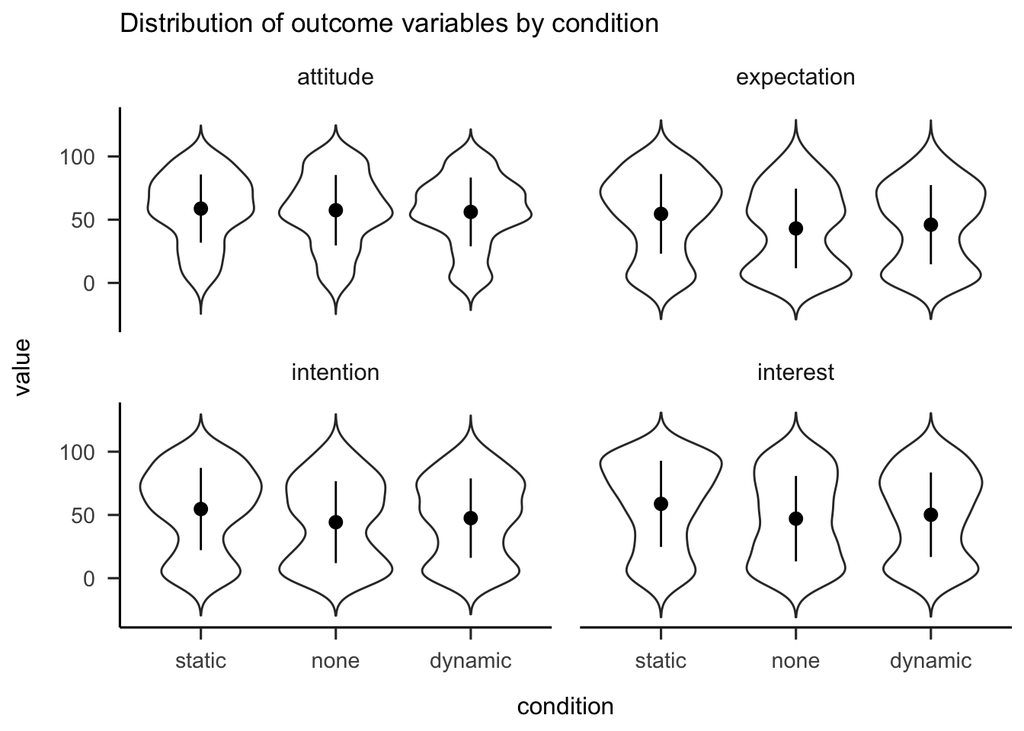

Figure 2.1: Violin plots of outcome variables by condition

```r
out_plots
```

```r
outcomes.tib %>%
  kable(caption = "Outcomes by condition ($M$ $\\pm$ $SD$)", digits = 2, escape = F) %>%
  add_header_above(c(" " = 1, "Conditions" = 3)) %>%
  kable_styling()
```

Table 2.2: Outcomes by condition ($M$ $\pm$ $SD$)

Conditions

Measure

Trending

Minority

None

1. Interest

49.58 $\pm$ 33.69

58.76 $\pm$ 34.15

46.64 $\pm$ 33.64

2. Attitude

56.03 $\pm$ 27.20

58.59 $\pm$ 27.36

58.26 $\pm$ 28.33

3. Intention

46.74 $\pm$ 31.65

54.89 $\pm$ 32.46

44.57 $\pm$ 32.76

4. Expectation

45.57 $\pm$ 31.56

54.03 $\pm$ 31.52

43.09 $\pm$ 31.64

```r
h1.table %>%
  kable(caption = "Path model (outcomes ~ condition)", row.names = F, escape = F, col.names = c("Model path", "$\\beta$", "$B$", "$SE$", "$z$", "$\\textit{p}$", "$LL$", "$UL$", "$B_{{H}(0, 5)}$", "RR", "Conclusion$^a$"), digits = 2) %>%
  add_header_above(c(" " = 6, "95% CI" = 2, "Bayesian inference" = 3)) %>%
  kable_styling() %>%
  pack_rows("Trending vs. minority", 1, 4) %>%
  pack_rows("Trending vs. none", 5, 8) %>%
  footnote(general_title = "Note.",
           general = paste0("CI = confidence interval; $LL$ = lower limit; $UL$ = upper limit. Model fit: $\\chi^2$(", h1.out$FIT[["baseline.df"]], ", N = ", h1.out$FIT[["ntotal"]], ") = ", round(h1.out$FIT[["baseline.chisq"]],2), ", $\\textit{p}$ ",
                            printp(h1.out$FIT[["baseline.pvalue"]]), "; CFI = ", printnum(h1.out$FIT[["cfi"]]), "; RMSEA = ", printnum(h1.out$FIT[["rmsea"]])),
           alphabet = c("H0 = evidence for null hypothesis, no = no conclusion, H1 = evidence for alternative hypothesis."),
           footnote_as_chunk = T)
```

Table 2.3: Path model (outcomes ~ condition)

| Model path | $\beta$ | $B$ | $SE$ | $z$ | $\textit{p}$ | 95% CI $LL$ | 95% CI $UL$ | Bayesian inference $B_{{H}(0, 5)}$ | Bayesian inference RR | Bayesian inference Conclusion$^a$ |
| --- | --- | --- | --- | --- | --- | --- | --- | --- | --- | --- |
| **Trending vs. minority** |  |  |  |  |  |  |  |  |  |  |
| interest | 9.18 | 0.13 | 3.09 | 2.97 | .003 | 3.12 | 15.23 | 0.15 | HN[2, 15] | H0 |
| attitude | 2.56 | 0.04 | 2.52 | 1.01 | .311 | -2.39 | 7.50 | 0.25 | HN[3.55, 15] | H0 |
| intention | 8.15 | 0.12 | 2.95 | 2.76 | .006 | 2.37 | 13.93 | 0.15 | HN[2.05, 15] | H0 |
| expectation | 8.46 | 0.13 | 2.88 | 2.94 | .003 | 2.81 | 14.11 | 0.14 | HN[1.9, 15] | H0 |
| **Trending vs. none** |  |  |  |  |  |  |  |  |  |  |
| interest | -2.95 | -0.04 | 3.11 | -0.95 | .344 | -9.05 | 3.16 | 1.15 | HN[0.05, 15] | no |
| attitude | 2.22 | 0.04 | 2.54 | 0.87 | .382 | -2.76 | 7.21 | 0.27 | HN[3.85, 15] | H0 |
| intention | -2.17 | -0.03 | 2.97 | -0.73 | .465 | -8.00 | 3.65 | 0.91 | HN[0.05, 15] | no |
| expectation | -2.48 | -0.04 | 2.91 | -0.85 | .394 | -8.17 | 3.22 | 1.01 | HN[0.05, 15] | no |

Note. CI = confidence interval; $LL$ = lower limit; $UL$ = upper limit. Model fit: $\chi^2$(14, N = 711) = 2632.55, $\textit{p}$ < .001; CFI = 1.00; RMSEA = 0.00  
<sup>a</sup> H0 = evidence for null hypothesis, no = no conclusion, H1 = evidence for alternative hypothesis.

## 2.3 Will participants in the trending minority norm condition be more likely (than minority norm only) to expect a decrease in meat consumption by British people?

```r
cons_desc[c(1:2, 6, 10)] %>%
  kable(caption = "Projected consumption average by condition", col.names = c("Condition", "n",  "$M$", "$SD$"), escape = F, digits = 2) %>%
  kable_styling()
```

Table 2.4: Projected consumption average by condition

| Condition | n | $M$ | $SD$ |
| --- | --- | --- | --- |
| static | 241 | 45.33 | 16.05 |
| none | 233 | 39.74 | 17.71 |
| dynamic | 237 | 44.99 | 15.56 |

## 2.4 Does the perceived current and future popularity of sustainable eating behaviours correlate with interest, attitudes, expectations, and intentions to limit own meat consumption?

```r
h3.table %>%
  kable(caption = "Path model (outcomes ~ projected consumption)", row.names = F, escape = F, col.names = c("Model path", "$\\beta$", "$B$", "$SE$", "$z$", "$\\textit{p}$", "$LL$", "$UL$", "$B_{{H}(0, 5)}$", "RR", "Conclusion$^a$"), digits = 2) %>%
  add_header_above(c(" " = 6, "95% CI" = 2, "Bayesian inference" = 3)) %>%
  kable_styling() %>%
  footnote(general_title = "Note.",
           general = paste0("CI = confidence interval; $LL$ = lower limit; $UL$ = upper limit. Model fit: $\\chi^2($", h3.out$FIT[["baseline.df"]], ", N = ", h3.out$FIT[["ntotal"]], ") = ", round(h3.out$FIT[["baseline.chisq"]],2), ", $\\textit{p}$ ",
                            printp(h3.out$FIT[["baseline.pvalue"]]), "; CFI = ", printnum(h3.out$FIT[["cfi"]]), "; RMSEA = ", printnum(h3.out$FIT[["rmsea"]])),
           alphabet = c("H0 = evidence for null hypothesis, no = no conclusion, H1 = evidence for alternative hypothesis."),
           footnote_as_chunk = T)
```

Table 2.5: Path model (outcomes ~ projected consumption)

| Model path | $\beta$ | $B$ | $SE$ | $z$ | $\textit{p}$ | 95% CI $LL$ | 95% CI $UL$ | Bayesian inference $B_{{H}(0, 5)}$ | Bayesian inference RR | Bayesian inference Conclusion$^a$ |
| --- | --- | --- | --- | --- | --- | --- | --- | --- | --- | --- |
| interest | 0.51 | 0.51 | 0.07 | 6.79 | < .001 | 0.36 | 0.65 | 1.489565e+08 | HN[0.05, 15] | H1 |
| attitude | 0.30 | 0.30 | 0.06 | 4.82 | < .001 | 0.18 | 0.42 | 2.318160e+03 | HN[0.05, 15] | H1 |
| intention | 0.46 | 0.46 | 0.07 | 6.51 | < .001 | 0.32 | 0.60 | 2.516551e+07 | HN[0.05, 15] | H1 |
| expectation | 0.53 | 0.53 | 0.07 | 7.61 | < .001 | 0.39 | 0.66 | 3.603938e+10 | HN[0.05, 15] | H1 |

## 2.5 Is projected meat consumption a mediator of the effect of trending minority norms vs. minority only on meat consumption outcomes?

```r
h4.table %>%
  kable(caption = "Mediation model", row.names = F, escape = F, col.names = c("Model path", "$\\beta$", "$B$", "$SE$", "$z$", "$\\textit{p}$", "$LL$", "$UL$"), digits = 2) %>%
  add_header_above(c(" " = 6, "95% CI" = 2)) %>%
  kable_styling() %>%
  pack_rows("Direct effects", 1, 11) %>%
  pack_rows("Indirect effects (~ condition > projected consumption)", 12, 15) %>%
  pack_rows("Total effects (~ condition + condition > projected consumption)", 16, 19) %>%
  footnote(general_title = "Note.",
           general = paste0("CI = confidence interval; $LL$ = lower limit; $UL$ = upper limit. Model fit: $\\chi^2$(", h4.out$FIT[["baseline.df"]], ", N = ", h4.out$FIT[["ntotal"]], ") = ", round(h4.out$FIT[["baseline.chisq"]],2), ", $\\textit{p}$ ",
                            printp(h4.out$FIT[["baseline.pvalue"]]), "; CFI = ", printnum(h4.out$FIT[["cfi"]]), "; RMSEA = ", printnum(h4.out$FIT[["rmsea"]])),
           footnote_as_chunk = T)
```

Table 2.6: Mediation model

| Model path | $\beta$ | $B$ | $SE$ | $z$ | $\textit{p}$ | 95% CI $LL$ | 95% CI $UL$ |
| --- | --- | --- | --- | --- | --- | --- | --- |
| **Direct effects** |  |  |  |  |  |  |  |
| ~ Projected consumption |  |  |  |  |  |  |  |
| Interest | 0.48 | 0.24 | 0.08 | 6.37 | < .001 | 0.34 | 0.64 |
| Attitude | 0.29 | 0.18 | 0.07 | 4.50 | < .001 | 0.16 | 0.42 |
| Intention | 0.45 | 0.23 | 0.07 | 6.17 | < .001 | 0.30 | 0.59 |
| Expectation | 0.51 | 0.26 | 0.07 | 7.29 | < .001 | 0.37 | 0.64 |
| ~ Condition |  |  |  |  |  |  |  |
| Interest | 9.21 | 0.13 | 2.63 | 3.50 | < .001 | 3.99 | 14.45 |
| Attitude | 0.59 | 0.01 | 2.14 | 0.28 | .783 | -3.66 | 4.80 |
| Intention | 7.92 | 0.12 | 2.52 | 3.14 | .002 | 2.96 | 12.95 |
| Expectation | 8.20 | 0.12 | 2.44 | 3.36 | .001 | 3.51 | 13.03 |
| Projected consumption | 2.94 | 0.08 | 1.28 | 2.30 | .022 | 0.44 | 5.46 |
| **Indirect effects (~ condition > projected consumption)** |  |  |  |  |  |  |  |
| Interest | 1.43 | 0.02 | 0.67 | 2.12 | .034 | 0.21 | 2.84 |
| Attitude | 0.86 | 0.01 | 0.43 | 1.99 | .046 | 0.12 | 1.83 |
| Intention | 1.31 | 0.02 | 0.62 | 2.11 | .034 | 0.19 | 2.62 |
| Expectation | 1.49 | 0.02 | 0.69 | 2.17 | .030 | 0.22 | 2.91 |
| **Total effects (~ condition + condition > projected consumption)** |  |  |  |  |  |  |  |
| Interest | 10.64 | 0.15 | 2.68 | 3.97 | < .001 | 5.38 | 16.01 |
| Attitude | 1.45 | 0.02 | 2.15 | 0.67 | .500 | -2.77 | 5.64 |
| Intention | 9.23 | 0.13 | 2.58 | 3.58 | < .001 | 4.20 | 14.35 |
| Expectation | 9.69 | 0.14 | 2.52 | 3.85 | < .001 | 4.84 | 14.59 |

Note. CI = confidence interval; $LL$ = lower limit; $UL$ = upper limit. Model fit: $\chi^2$(15, N = 711) = 2689.69, $\textit{p}$ < .001; CFI = 1.00; RMSEA = 0.00

## 2.6 How do demographic factors such as age, gender, and political position predict primary dependent variables relating to meat consumption?

```r
h5.table %>%
  kable(caption = "Full model", row.names = F, escape = F, col.names = c("Model path", "$\\beta$", "$B$", "$SE$", "$z$", "$\\textit{p}$", "$LL$", "$UL$"), digits = 2) %>%
  add_header_above(c(" " = 6, "95% CI" = 2)) %>%
  kable_styling() %>%
  pack_rows(paste0("Interest ~ ($R$ = ", scales::percent(h5.out$PE[46,5]), ")"), 1, 5) %>%
  pack_rows(paste0("Attitude ~ ($R$ = ", scales::percent(h5.out$PE[47,5]), ")"), 6, 10) %>%
  pack_rows(paste0("Intention ~ ($R$ = ", scales::percent(h5.out$PE[48,5]), ")"), 11, 15) %>%
  pack_rows(paste0("Expectation ~ ($R$ = ", scales::percent(h5.out$PE[49,5]), ")"), 16, 20) %>%
  footnote(general_title = "Note.",
           general = paste0("CI = confidence interval; $LL$ = lower limit; $UL$ = upper limit. Model fit: $\\chi^2$(", h5.out$FIT[["baseline.df"]], ", N = ", h5.out$FIT[["ntotal"]], ") = ", round(h5.out$FIT[["baseline.chisq"]],2), ", $\\textit{p}$ ",
                            printp(h5.out$FIT[["baseline.pvalue"]]), "; CFI = ", printnum(h5.out$FIT[["cfi"]]), "; RMSEA = ", printnum(h5.out$FIT[["rmsea"]])),
           alphabet = c("Trending compared to minority norms; ", "Binary coded, 0 = Male, 1 = Female; ", "Scaled from left to right wing"))
```

Table 2.7: Full model

| Model path | $\beta$ | $B$ | $SE$ | $z$ | $\textit{p}$ | 95% CI $LL$ | 95% CI $UL$ |
| --- | --- | --- | --- | --- | --- | --- | --- |
| **Interest ~ ($R$ = 13%)** |  |  |  |  |  |  |  |
| Condition$^a$ | 7.90 | 0.11 | 2.56 | 3.09 | .002 | 2.89 | 12.91 |
| Projected consumption | 0.46 | 0.22 | 0.07 | 6.26 | < .001 | 0.31 | 0.60 |
| Age | -0.02 | -0.01 | 0.10 | -0.24 | .814 | -0.22 | 0.17 |
| Gender$^b$ | 10.69 | 0.15 | 2.56 | 4.18 | < .001 | 5.68 | 15.70 |
| Politics$^c$ | -5.05 | -0.17 | 1.04 | -4.84 | < .001 | -7.09 | -3.00 |
| **Attitude ~ ($R$ = 7%)** |  |  |  |  |  |  |  |
| Condition$^a$ | -0.13 | 0.00 | 2.13 | -0.06 | .950 | -4.30 | 4.04 |
| Projected consumption | 0.27 | 0.16 | 0.06 | 4.47 | < .001 | 0.15 | 0.39 |
| Age | 0.04 | 0.02 | 0.08 | 0.48 | .629 | -0.12 | 0.21 |
| Gender$^b$ | 10.02 | 0.17 | 2.13 | 4.71 | < .001 | 5.85 | 14.19 |
| Politics$^c$ | -2.77 | -0.12 | 0.87 | -3.19 | .001 | -4.47 | -1.07 |
| **Intention ~ ($R$ = 12%)** |  |  |  |  |  |  |  |
| Condition$^a$ | 6.73 | 0.10 | 2.44 | 2.76 | .006 | 1.95 | 11.50 |
| Projected consumption | 0.42 | 0.21 | 0.07 | 6.04 | < .001 | 0.28 | 0.56 |
| Age | 0.10 | 0.04 | 0.10 | 1.03 | .301 | -0.09 | 0.29 |
| Gender$^b$ | 11.23 | 0.16 | 2.44 | 4.61 | < .001 | 6.45 | 16.01 |
| Politics$^c$ | -4.79 | -0.17 | 0.99 | -4.82 | < .001 | -6.74 | -2.84 |
| **Expectation ~ ($R$ = 13%)** |  |  |  |  |  |  |  |
| Condition$^a$ | 7.29 | 0.11 | 2.37 | 3.07 | .002 | 2.64 | 11.94 |
| Projected consumption | 0.49 | 0.26 | 0.07 | 7.24 | < .001 | 0.36 | 0.62 |
| Age | 0.18 | 0.07 | 0.09 | 1.87 | .062 | -0.01 | 0.36 |
| Gender$^b$ | 7.91 | 0.12 | 2.38 | 3.33 | .001 | 3.26 | 12.57 |
| Politics$^c$ | -4.53 | -0.16 | 0.97 | -4.67 | < .001 | -6.42 | -2.63 |

Note.  
CI = confidence interval; $LL$ = lower limit; $UL$ = upper limit. Model fit: $\chi^2$(26, N = 706) = 2741.45, $\textit{p}$ < .001; CFI = 1.00; RMSEA = 0.00  
<sup>a</sup> Trending compared to minority norms;  
<sup>b</sup> Binary coded, 0 = Male, 1 = Female;  
<sup>c</sup> Scaled from left to right wing

# 3 Codebook

```r
codebook::codebook_table(clean) %>% kable()
```

name

label

data_type

ordered

value_labels

n_missing

complete_rate

n_unique

top_counts

min

median

max

mean

sd

n_value_labels

hist

dynamic

static

none

format.spss

display_width

nationality

Nationality

factor

FALSE

0

1.0000000

15

Bri: 694, Ame: 2, Ita: 2, Nig: 2

country

Country

factor

FALSE

1. English,

Welsh,

Scottish,

Northern Irish

17

0.9760900

4

Eng: 606, Sco: 50, Wel: 24, Nor: 14

resident

Residency

factor

FALSE

1. Yes,

No

0

1.0000000

2

Yes: 704, No: 7

condition

condition

factor

FALSE

1. static,

none,

dynamic

0

1.0000000

3

sta: 241, dyn: 237, non: 233

1

2

3

interest

Interest

numeric

0

1.0000000

0.00

54.0

100.0

51.7271449

34.1795810

▇▅▅▆▇

F40.2

0

attitude

Attitude

numeric

0

1.0000000

0.00

59.0

100.0

57.6286920

27.6152126

▃▃▇▇▆

F40.2

0

intention

Intention

numeric

0

1.0000000

0.00

52.0

100.0

48.7932489

32.5507320

▇▃▆▇▆

F40.2

0

expectation

Expectation

numeric

0

1.0000000

0.00

52.0

100.0

47.6258790

31.8741912

▇▃▅▇▅

F40.2

0

cons_now_perc

Percentage this year - Percentage of people (%)

numeric

0

1.0000000

0.00

35.0

80.0

35.4233474

15.8239243

▃▇▇▃▁

F40.2

0

cons_next_perc

Percentage next year - Percentage of people (%)

numeric

0

1.0000000

0.00

40.0

88.0

40.7918425

18.0574667

▃▇▇▆▁

F40.2

0

cons_six_perc

Percentage six years - Percentage of people (%)

numeric

0

1.0000000

0.00

55.0

100.0

53.9338959

20.5043415

▂▅▇▇▂

F40.2

0

politics

Political ideology

numeric

0

1.0000000

1.00

4.0

7.0

3.5147679

1.1637693

▅▅▇▂▁

F40.2

0

age

Age

numeric

0

1.0000000

18.00

32.0

76.0

34.2756681

11.9844952

▇▇▂▂▁

F40.2

0

gender

Gender

factor

FALSE

1. Male,

Female,

Other

0

1.0000000

3

Fem: 466, Mal: 240, Oth: 5

meat_cons

Days meat consumed last week

numeric

0

1.0000000

0.00

5.0

7.0

4.7510549

1.7234655

▁▂▇▅▇

F40.2

0

norm_time_Page_Submit

Timing - Page Submit

numeric

0

1.0000000

0.78

7.8

127.3

10.4599733

11.8150973

▇▁▁▁▁

F40.2

0

conformity_1

Conformity - I often compare how I am doing socially (e.g., social skills, popularity) with other people.

haven_labelled

1. Strongly disagree,

Disagree,

Somewhat disagree,

Neither agree nor disagree,

Somewhat agree,

Agree,

Strongly agree

0

1.0000000

1

4

7

4.0407876

1.7658008

7

▂▅▅▃▁▇▅▂

F40.0

0

conformity_2

Conformity - I always pay a lot of attention to how I do things compared with how others do things.

haven_labelled

1. Strongly disagree,

Disagree,

Somewhat disagree,

Neither agree nor disagree,

Somewhat agree,

Agree,

Strongly agree

0

1.0000000

1

5

7

4.4177215

1.5044239

7

▁▂▃▃▁▇▅▁

F40.0

0

conformity_3

numeric

0

1.0000000

1.00

4.0

7.0

4.0886076

1.6069469

▆▇▆▇▇

conformity_4

Conformity - I always like to know what others in a similar situation would do.

haven_labelled

1. Strongly disagree,

Disagree,

Somewhat disagree,

Neither agree nor disagree,

Somewhat agree,

Agree,

Strongly agree

0

1.0000000

1

5

7

4.7313643

1.3560976

7

▁▂▂▃▁▇▆▁

F40.0

0

conformity_5

Conformity - I often try to find out what others think who face similar problems as I face.

haven_labelled

1. Strongly disagree,

Disagree,

Somewhat disagree,

Neither agree nor disagree,

Somewhat agree,

Agree,

Strongly agree

0

1.0000000

1

5

7

4.8255977

1.2926521

7

▁▁▂▃▁▇▅▁

F40.0

0

conformity_6

Conformity - If I want to learn more about something, I try to find out what others think about it.

haven_labelled

1. Strongly disagree,

Disagree,

Somewhat disagree,

Neither agree nor disagree,

Somewhat agree,

Agree,

Strongly agree

0

1.0000000

1

5

7

4.6427567

1.3856712

7

▁▂▂▃▁▇▃▁

F40.0

0

att_checkbi

factor

FALSE

1. 0,

1

0

1.0000000

2

1: 664, 0: 47

cons_proj

numeric

0

1.0000000

1.67

44.3

83.3

43.3830286

16.6294617

▂▆▇▇▂

genderbi

factor

FALSE

1. -1,

1

5

0.9929677

2

1: 466, -1: 240

conformity_mean

numeric

0

1.0000000

1.00

4.5

6.7

4.4282700

0.8422133

▁▂▆▇▁

dynamic

numeric

0

1.0000000

0.00

0.0

1.0

0.3333333

0.4717364

▇▁▁▁▃

static

numeric

0

1.0000000

0.00

0.0

1.0

0.3389592

0.4736892

▇▁▁▁▅

none

numeric

0

1.0000000

0.00

0.0

1.0

0.3277075

0.4697080

▇▁▁▁▃